# *Mahalanobis Distance*

*Mahalanobis distance is an effective multivariate distance metric that measures the distance between a point (vector) and a distribution.*

*It has excellent applications in multivariate anomaly detection, classification on highly imbalanced datasets and one-class classification and more untapped use cases.*

## *What’s wrong with using Euclidean Distance for Multivariate data?*

*Euclidean distance is the commonly used straight line distance between two points.*

*If the two points are in a two-dimensional plane (meaning, you have two numeric columns (p) and (q)) in your dataset), then the Euclidean distance between the two points (p1, q1) and (p2, q2) is:*

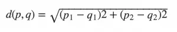

*This formula may be extended to as many dimensions you want:*

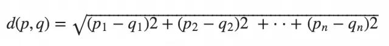

*Well, Euclidean distance will work fine as long as the dimensions are equally weighted and are independent of each other.*

*What do I mean by that?*

*Let’s consider the following tables:*

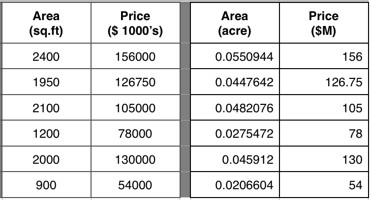

_

*The two tables above show the ‘area’ and ‘price’ of the same objects. Only the units of the variables change.*

*Since both tables represent the same entities, the distance between any two rows, point A and point B should be the same. But Euclidean distance gives a different value even though the distances are technically the same in physical space.*

*This can technically be overcome by scaling the variables, by computing the z-score (ex: (x – mean) / std) or make it vary within a particular range like between 0 and 1.*

*But there is another major drawback.*

*That is, if the dimensions (columns in your dataset) are correlated to one another, which is typically the case in real-world datasets, the Euclidean distance between a point and the center of the points (distribution) can give little or misleading information about how close a point really is to the cluster.*

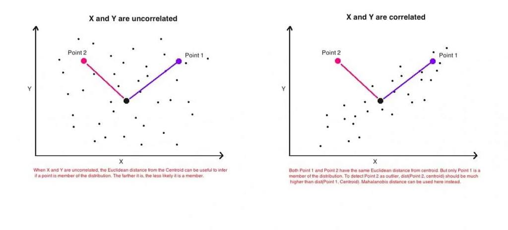

*The above image (on the right) is a simple scatterplot of two variables that are positively correlated with each other. That is, as the value of one variable (x-axis) increases, so does the value of the other variable (y-axis).*

*The two points above are equally distant (Euclidean) from the center. But only one of them (blue) is actually more close to the cluster, even though, technically the Euclidean distance between the two points are equal.*

*This is because, Euclidean distance is a distance between two points only. It does not consider how the rest of the points in the dataset vary. So, it cannot be used to really judge how close a point actually is to a distribution of points.*

*What we need here is a more robust distance metric that is an accurate representation of how distant a point is from a distribution.*

## *What is Mahalanobis Distance?*

*Mahalonobis distance is the distance between a point and a distribution. And not between two distinct points. It is effectively a multivariate equivalent of the Euclidean distance.*

*So computationally, how is Mahalanobis distance different from Euclidean distance?*

- *It transforms the columns into uncorrelated variables*
- *Scale the columns to make their variance equal to 1*
- *Finally, it calculates the Euclidean distance.*

*The formula to compute Mahalanobis distance is as follows:*

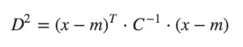

```
where,
 - D^2        is the square of the Mahalanobis distance.
 - x          is the vector of the observation (row in a dataset),
 - m          is the vector of mean values of independent variables (mean of each column),
 - C^(-1)     is the inverse covariance matrix of independent variables.
```

*So, how to understand the above formula?*

*Let’s take the (x – m)^T . C^(-1) term.*

*(x – m) is essentially the distance of the vector from the mean. We then divide this by the covariance matrix (or multiply by the inverse of the covariance matrix).*

*If you think about it, this is essentially a multivariate equivalent of the regular standardization (z = (x – mu)/sigma). That is, z = (x vector) – (mean vector) / (covariance matrix).*

*So, What is the effect of dividing by the covariance?*

*If the variables in your dataset are strongly correlated, then, the covariance will be high. Dividing by a large covariance will effectively reduce the distance.*

*Likewise, if the X’s are not correlated, then the covariance is not high and the distance is not reduced much.*

*So effectively, it addresses both the problems of scale as well as the correlation of the variables that we talked about in the introduction.*

*First, we calculate the Mahalanobis distance for all instances and then, we decide a threshold for Mahalanobis distance beyond which an instance can be tagged as an anomaly or as a suspicious instance.*

## *Multivariate Outlier Detection*

```python
import pandas as pd
import numpy as np

filepath = 'https://raw.githubusercontent.com/selva86/datasets/master/diamonds.csv'
df = pd.read_csv(filepath).iloc[:, [0,4,6]]
df.head()
```

|  | carat | depth | price |
| --- | --- | --- | --- |
| 0 | 0.23 | 61.5 | 326 |
| 1 | 0.21 | 59.8 | 326 |
| 2 | 0.23 | 56.9 | 327 |
| 3 | 0.29 | 62.4 | 334 |
| 4 | 0.31 | 63.3 | 335 |

```python
def mahalanobis(x=None, data=None, cov=None):
    """Compute the Mahalanobis Distance between each row of x and the data
    x    : vector or matrix of data with, say, p columns.
    data : ndarray of the distribution from which Mahalanobis distance of each observation of x is to be computed.
    cov  : covariance matrix (p x p) of the distribution. If None, will be computed from data.
    """
    x_minus_mu = x - np.mean(data)
    if not cov:
        cov = np.cov(data.values.T)
    inv_covmat = np.linalg.inv(cov)
    left_term = np.dot(x_minus_mu, inv_covmat)
    mahal = np.dot(left_term, x_minus_mu.T)
    return mahal.diagonal()
```

```python
df_x = df[['carat', 'depth', 'price']].head(500)
df_x['mahala'] = mahalanobis(x=df_x, data=df[['carat', 'depth', 'price']])
df_x.head()
```

|  | carat | depth | price | mahala |
| --- | --- | --- | --- | --- |
| 0 | 0.23 | 61.5 | 326 | 1.709860 |
| 1 | 0.21 | 59.8 | 326 | 3.540097 |
| 2 | 0.23 | 56.9 | 327 | 12.715021 |
| 3 | 0.29 | 62.4 | 334 | 1.454469 |
| 4 | 0.31 | 63.3 | 335 | 2.347239 |

*Assuming that the test statistic follows chi-square distributed with ‘n’ degree of freedom, the critical value at a 0.01 significance level and 2 degrees of freedom is computed as:*

```python
# Critical values for two degrees of freedom
from scipy.stats import chi2
chi2.ppf((1-0.01), df=2)
```

```
9.21034037197618
```

*That mean an observation can be considered as extreme if its Mahalanobis distance exceeds 9.21.*

*If you prefer P values instead to determine if an observation is extreme or not, the P values can be computed as follows:*

```python
# Compute the P-Values
df_x['p_value'] = 1 - chi2.cdf(df_x['mahala'], 2)

# Extreme values with a significance level of 0.01
df_x.loc[df_x.p_value < 0.01].head(10)
```

|  | carat | depth | price | mahala | p_value |
| --- | --- | --- | --- | --- | --- |
| 2 | 0.23 | 56.9 | 327 | 12.715021 | 0.001734 |
| 91 | 0.86 | 55.1 | 2757 | 23.909643 | 0.000006 |
| 97 | 0.96 | 66.3 | 2759 | 11.781773 | 0.002765 |
| 172 | 1.17 | 60.2 | 2774 | 9.279459 | 0.009660 |
| 204 | 0.98 | 67.9 | 2777 | 20.086616 | 0.000043 |
| 221 | 0.70 | 57.2 | 2782 | 10.405659 | 0.005501 |
| 227 | 0.84 | 55.1 | 2782 | 23.548379 | 0.000008 |
| 255 | 1.05 | 65.8 | 2789 | 11.237146 | 0.003630 |
| 284 | 1.00 | 58.2 | 2795 | 10.349019 | 0.005659 |
| 298 | 1.01 | 67.4 | 2797 | 17.716144 | 0.000142 |

*[Reference 1](https://www.machinelearningplus.com/statistics/mahalanobis-distance/)* *[Reference 2](https://blog.clairvoyantsoft.com/mlmuse-approaches-to-outlier-detection-part-2-2ecb909a98f9)*